# Demografi: opgaver 8

# Opgave 1

1. Find antallet af fødsler og risikotiden for kvinder, som er mellem 15 og 49 år, i 2019 i statistikbankens `FOD` og `FOLK1a`:
   - Beregn aldersspecifikke fertilitetsrater per 1000 personår per 1000 kvinder.
   - Baseret på disse tal, hvor mange børn vil 120 kvinder forventes at få mellem deres 25. og 40. fødselsdag? Angiv resultatet i en sætning med den rigtige fortolkning, som tager højde for at alle tal er fra 2019.
2. Find året 2019 i statistikbankens FOD407. Denne tabel viser aldersspecifikke fertilitetsrater (de kalder dem fertilitetskvotienter) og også den samlede fertilitet. Hvad kunne være en plausibel forklaring hvorfor deres tal afviger fra vores beregninger baseret på `FOD` og `FOLK1a`?
3. Hvilke enheder har hhv., brutto- og nettoreproduktionstal?
4. Hvor højt skal værdien af nettoreproduktionstallet være, hvis befolkningen skal kunne reproducere sige selv? Begrund dit svar.
5. Hvilke fertilitetsmål afhænger kvinders aldersfordeling af og hvilke gør ikke? Fertilitetsmål er
   - summariske fertilitetsrate
   - generelle fertilitetsrate
   - aldersspecifikke fødselsrater
   - samlet fertilitet
   - brutto- og nettoreproduktionstal

## Aldersspecifikke fertilitetsrater

```r
f19 <- hent_fertilitetsrate_data(tid = 2019)
f19 <- f19 %>% mutate(fertilitetsrate=1000*Fødsler/R)
f19
```

```
# A tibble: 7 × 5
  aldersinterval   TID      R Fødsler fertilitetsrate
  <fct>          <dbl>  <dbl>   <dbl>           <dbl>
1 15-19           2019 167128     339           2.03
2 20-24           2019 188337    5454          29.0
3 25-29           2019 195241   20864         107.
4 30-34           2019 172958   22097         128.
5 35-39           2019 163456    9940          60.8
6 40-44           2019 184048    2303          12.5
7 45-49           2019 194866     163           0.836
```

## Børn, som 120 kvinder vil forventes at få mellem deres 25. og 40. fødselsdag

Bemærk: Tallet minder om den samlede fertilitet for 120 (som dog inkludrer flere aldersintervaller).

Tallet kan også findes i R:

```r
f19 %>% filter(aldersinterval %in% c("25-29","30-34","35-39")) %>% summarize(res = sum(fertilitetsrate*5*0.12))
```

```
# A tibble: 1 × 1
    res
  <dbl>
1  177.
```

Udregningen består af følgende dele: - Ingen dør i perioden. - De aldersspecifikke rater forbliver det samme. Kvinderne starter altså som 25 årige og føder $106,9 \cdot 0.12$ børn, året er de 26 og føder $106,9 \cdot 0.12$ børn, …, året efter er de 30 og føder $127.8 \cdot 0,12$ børn, osv.

## Afvigelser i DST fra vores beregninger

| Tid | Samlet fertilitet | 15-19 år | 20-24 år | 25-29 år | 30-34 år | 35-39 år | 40-44 år | 45-49 år |
| --- | --- | --- | --- | --- | --- | --- | --- | --- |
| 2019 | 1699.4 | 1.3 | 23.6 | 99.5 | 130.7 | 67.9 | 15.7 | 1.1 |

En plausibel forklaring er at der bliver brugt en anden metode til udregningen af risikotiden (Metode 2 eller 3).

## Enheder og hvor højt skal værdien af nettoreproduktionstallet være, hvis befolkningen skal kunne reproducere sige selv?

3. Antal børn. Fordi vi ganger fødselsrater som har enhed antal børn per (1000) personår med (5) personår.
4. Det skal være mindst 1, fordi så ville hver kvinde få mindst en pige, som selv får mindst en pige, osv.

## Hvilke fertilitetsmål afhænger kvinders aldersfordeling af?

Bruger vi de aldersspecifikke fødselsrater i udregningen. Hvis ja, så afhænger de ikke af kvindernes aldersfordeling.

Afhænger af kvinders aldersfordeling:

- summariske fertilitetsrate
- generelle fertilitetsrate

Afhænger ikke af kvinders aldersfordeling:

- aldersspecifikke fødselsrater
- samlet fertilitet
- brutto- og nettoreproduktionstal

# Opgave 2

1. For at sammenligne fertilitet mellem kommunerne Albertslund og Skanderborg i perioden 2010-2019, beregn og fortolk for begge kommuner separat følgende fertilitetsmål:
   - summariske og generelle fertilitetsrater
   - alderspecifikke fertilitetsrater
   - den samlede fertilitet
   - brutto- og nettoreproduktionstal
2. Tegn kvindernes aldersfordeling for begge kommuner blandt 15-49 årige i en graf. Beskriv hvad grafen viser.
3. Tegn alderspecifikke fertilitetsrater for begge kommuner i en graf. Beskriv hvad grafen viser.
4. Diskuter forskelle mellem Albertslund og Skanderborg og overvej årsagerne.

## Summarisk fertilitetsrate

$$f_{sum} = \frac{_{35}F_{15}[2010,2019]}{R[2010,2019]}$$

```r
# antal fødsler per år
antal_F <- hent_data("fodie",
                     tid = 2010:2019,
                     område = c("Albertslund","Skanderborg"))
# total antal fødsler i perioden
total_F <- antal_F %>%
  group_by(OMRÅDE) %>%
  summarise(F = sum(INDHOLD))
N <- hent_data("folk1a",
               tid = paste0(c(2010,2020),"K1"),
               område = c("Albertslund","Skanderborg"))
# risikotid alle danskere (metode 2)
R <- N %>% group_by(OMRÅDE) %>%
  summarise(R = 10*mean(INDHOLD),.groups = "drop") #Periodelængde * Middelfolketal = Risikotid
left_join(total_F,R) %>%
  mutate(summ_frate = 1000*F/R)
```

```
# A tibble: 2 × 4
  OMRÅDE          F      R summ_frate
  <chr>       <dbl>  <dbl>      <dbl>
1 Albertslund  2857 277305       10.3
2 Skanderborg  6329 599905       10.6
```

## Generel fertilitetsrate

$$f_{gen} = \frac{_{35}F_{15}[2010,2019]}{_{35}R^{\text{Kvinder}}_{15}[2010,2019]}$$

```r
# middelfolketal kvinder mellem 15 og 49 (metode 2)
N_kvinder <- hent_data("folk1a",
                       alder = 15:49,
                       køn = "kvinder",
                       tid = paste0(c(2010,2020),"K1"),
                       område = c("Albertslund","Skanderborg"))
N_kvinder <- N_kvinder %>%
  group_by(OMRÅDE,TID) %>%
  summarise(N = sum(INDHOLD))
# risikotid kvinder mellem 15 og 49 år
R_kvinder <- N_kvinder %>%
  group_by(OMRÅDE) %>%
  summarise(R = 10*mean(N),.groups = "drop")
# generelle fertilitetsrate
left_join(total_F,R_kvinder) %>%
  mutate(gen_frate = 1000*F/R)
```

```
# A tibble: 2 × 4
  OMRÅDE          F      R gen_frate
  <chr>       <dbl>  <dbl>     <dbl>
1 Albertslund  2857  64015      44.6
2 Skanderborg  6329 128115      49.4
```

## Samlet fertilitetsrate

$$\quad f_{samlet}=5\cdot _5f_{15}+5\cdot _5f_{20}+...+5\cdot_5f_{45}.$$

```r
# data fra Albertslund
fa <- fertilitets_tavle(tid = 2010:2019,område = "Albertslund")
# data fra Skanderborg
fs <- fertilitets_tavle(tid = 2010:2019,område = "Skanderborg")
# samlet fertilitet
fa %>% summarize(samlet_fertilitet = sum(frate*5))
```

```
# A tibble: 1 × 1
  samlet_fertilitet
              <dbl>
1              1.71
```

```r
fs %>% summarize(samlet_fertilitet = sum(frate*5))
```

```
# A tibble: 1 × 1
  samlet_fertilitet
              <dbl>
1              2.24
```

## Bruttoreproduktionstal

$$\quad \operatorname{BRT} = {}_5{f}_{20}^{\text{piger}}+...+5\cdot {}_5{f}_{45}^{\text{piger}}$$

```r
# BRT
fa %>% summarize(BRT = sum(frate_piger*5))
```

```
# A tibble: 1 × 1
    BRT
  <dbl>
1 0.834
```

```r
fs %>% summarize(BRT = sum(frate_piger*5))
```

```
# A tibble: 1 × 1
    BRT
  <dbl>
1  1.07
```

## Nettoreproduktionstal

$$\quad \operatorname{NRT}=_5\negthickspace{f}_{15}^{\text{piger}}\frac{_5L_{15}}{\ell_0}+
_5\negthickspace{f}_{20}^{\text{piger}}\frac{_5 L_{20}}{\ell_0}+...+
_5\negthickspace{f}_{45}^{\text{piger}}\frac{_5L_{45}}{\ell_0}$$

```r
# NRT
fa <- mutate(fa,bidrag_NRT=frate_piger*L/100000)
fs <- mutate(fs,bidrag_NRT=frate_piger*L/100000)
fa %>% summarize(NRT = sum(bidrag_NRT))
```

```
# A tibble: 1 × 1
    NRT
  <dbl>
1 0.829
```

```r
fs %>% summarize(NRT = sum(bidrag_NRT))
```

```
# A tibble: 1 × 1
    NRT
  <dbl>
1  1.06
```

## Kommentarer

Bruttoproduktionstal og nettoreproduktionstal har som forventet næsten samme værdi i begge kommuner. Det skyldes den lave mortalitet (i aldersgruppen op til 50). Tallene for Albertslund ligger en del under og tallene i Skanderborg ligger lige ved reproduktionsgrænsen.

## Aldersfordeling

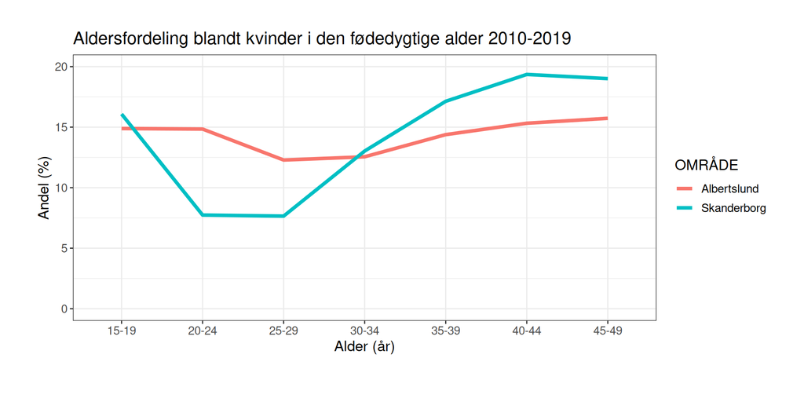

```r
fa <- fa %>% mutate(Aldersfordeling=100*R/sum(R))
fs <- fs %>% mutate(Aldersfordeling=100*R/sum(R))
fdata <- rbind(fa,fs)
g <- ggplot(fdata,aes(aldersinterval,Aldersfordeling,group=OMRÅDE,color=OMRÅDE))+geom_line(linewidth=1.5)
g <- g+theme_bw()+theme(text = element_text(size=13))+ylab("Andel (%)")+theme(plot.margin=unit(c(1,1,1.5,1.2),"cm"))
g+xlab("Alder (år)")+ylim(c(0,20))+ggtitle("Aldersfordeling blandt kvinder i den fødedygtige alder 2010-2019")
```

## Kommentarer

Grafen viser aldersfordelingen af risikotiden fra kvinder i kommunerne Albertslund og Skanderborg i perioden 2010-2019. I Skanderborg er der betydeligt færre kvinder i aldersgrupperne 20-24 og 25-29 end i Albertslund.

## Fødselsrate

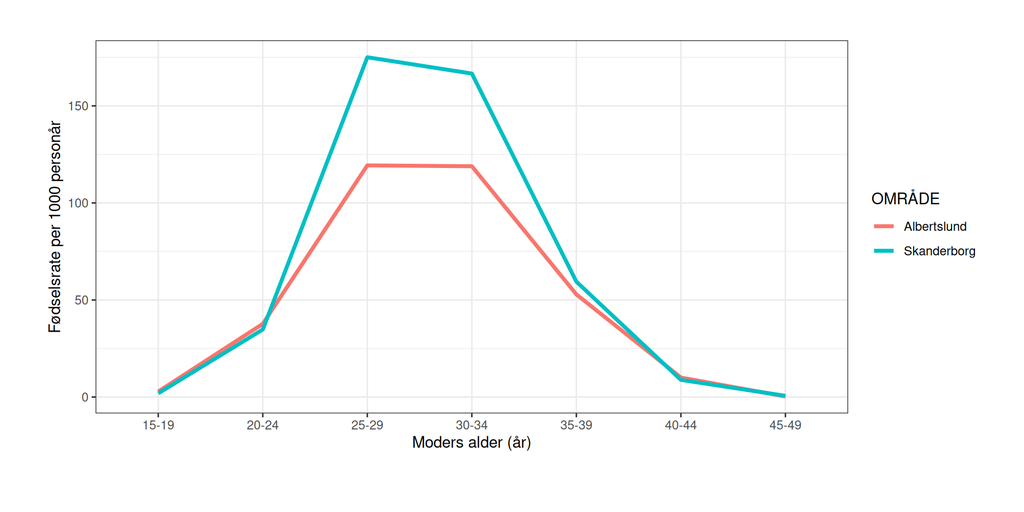

```r
g1 <- ggplot(fdata,aes(aldersinterval,1000*frate,color= OMRÅDE,group= OMRÅDE))+geom_line(linewidth=1.3)
g1 <- g1+ylab("Fødselsrate per 1000 personår")+xlab("Moders alder (år)")+theme_bw()+theme(plot.margin=unit(c(1,1,1.5,1.2),"cm"))
g1
```